# Online Retail Report

## Find Outliers in gpa

Also after I visualize gpa data in Box plot I found its has outliers as well so i removed the outliers

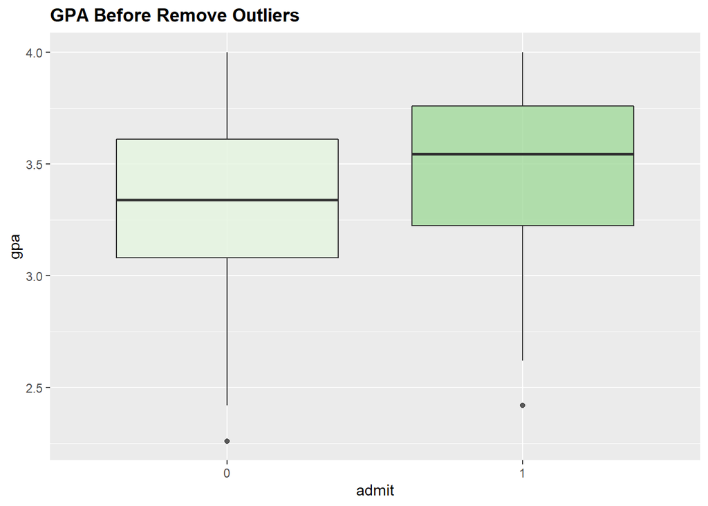

I used boxplot.stats to get the indexs of the outliers. which are:

```
## [1] 288
```

[output not shown]

Here is the outliers entire row:

Now I check boxplot again to see change in it after remove outiers.

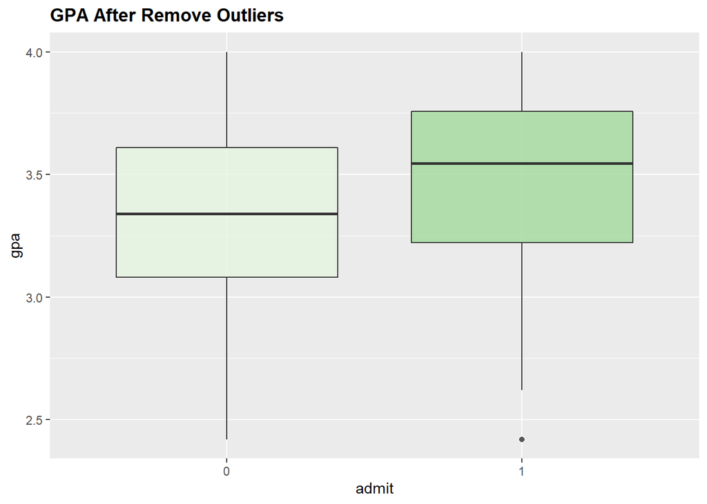

# Data Visualization

First I visualize the numeric values in my data to understand it better and see what I can do if I want to use it in my analysis.  
I want to find whether the data is normally distributed or not so I use a density plot to represent the distribution of a numeric variable. Since it shows the probability density function of the variable.  
A normal distribution of data is one in which the majority of data points are relatively similar, meaning they occur within a small range of values with fewer outliers on the high and low ends of the data range and I did this to see how strong the gpa and gre are.

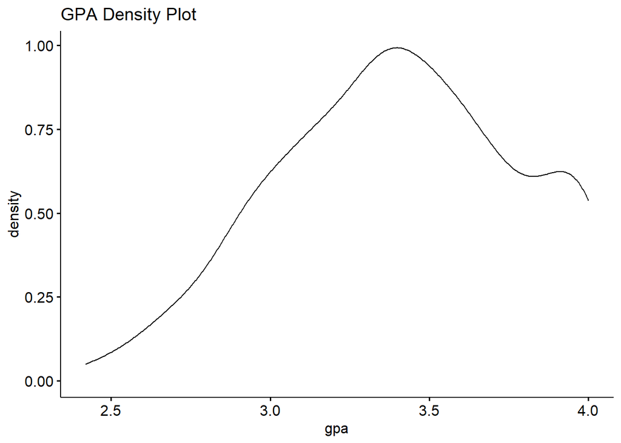

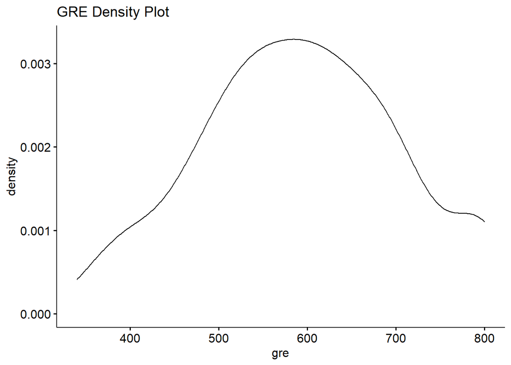

I want to test the normality further so I used The R function `shapiro.test()` can be used to perform the Shapiro-Wilk test of normality for one variable (univariate):

Here is GPA Shapiro Test result:

```
##
##  Shapiro-Wilk normality test
##
## data:  coladm$gpa
## W = 0.97646, p-value = 5.004e-06
```

Here is GRE Shapiro Test result:

```
##
##  Shapiro-Wilk normality test
##
## data:  coladm$gre
## W = 0.98282, p-value = 0.0001223
```

So After applying log transformation and retest the values using Shapiro Test the results are :

GPA Shapiro Test result after log transformation:

```
##
##  Shapiro-Wilk normality test
##
## data:  coladm$gpa
## W = 0.96991, p-value = 2.852e-07
```

GRE Shapiro Test result after log transformation:

```
##
##  Shapiro-Wilk normality test
##
## data:  coladm$gre
## W = 0.97129, p-value = 5.057e-07
```

Plot the density plot for GPA and GRE again to see the different in the plot.

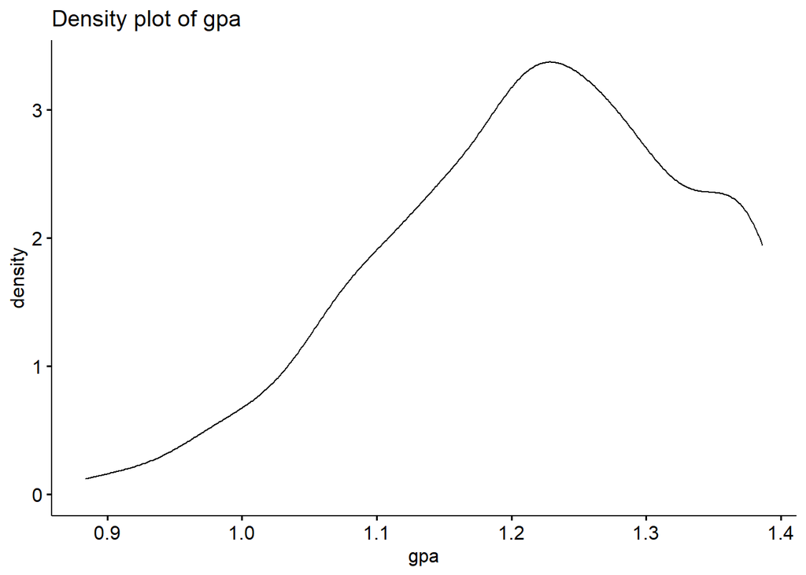

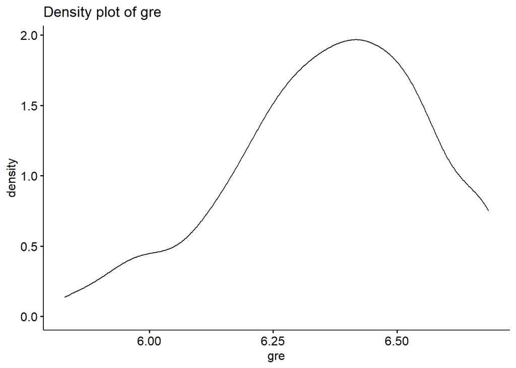

# Variable Reduction Techniques

Use variable reduction techniques to identify significant variables.  
Here I wanted to see if I can use gpa to predict the gre.

Here I plot gpa and gre to see their relation and found that they do relate to each other but not enough to use it to predict one of it. Also having small data here is disadvantage for this prediction.

So I will not use gre to predict gpa in this analysis.

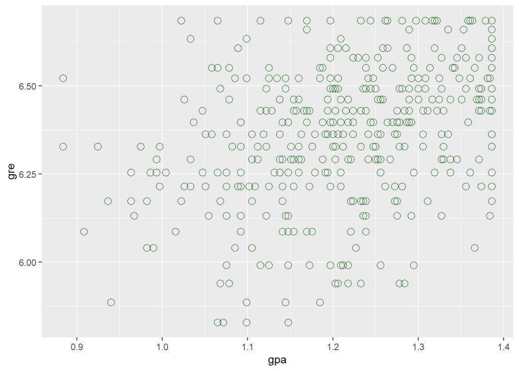

# Modeling

In a small dataset is better to choose simple models. Complex models with many parameters are more prone to overfitting which I want to avoid. In this analysis, I will experiment with a prediction using the following models:  
* Logistic Regression  
* GBM  
* Random Forests

And see how each model will preform.

## Logistic Regression

Fit the logistic regression model for all predictors.

```
##
## Call:
## glm(formula = admit ~ ., family = "binomial", data = coladm_train)
##
## Deviance Residuals:
##     Min       1Q   Median       3Q      Max
## -1.7217  -0.8737  -0.6313   1.1542   2.1766
##
## Coefficients:
##              Estimate Std. Error z value Pr(>|z|)
## (Intercept)  -10.9502     4.4895  -2.439  0.01472 *
## gre            1.4158     0.7420   1.908  0.05639 .
## gpa            2.1709     1.3351   1.626  0.10395
## ses2          -0.1647     0.3318  -0.496  0.61963
## ses3          -0.5996     0.3506  -1.710  0.08728 .
## Gender_Male1  -0.1470     0.2774  -0.530  0.59625
## Race2         -0.2247     0.3360  -0.669  0.50363
## Race3         -0.2208     0.3336  -0.662  0.50817
## rank2         -0.8585     0.4017  -2.137  0.03259 *
## rank3         -1.3891     0.4353  -3.191  0.00142 **
## rank4         -1.8636     0.5264  -3.540  0.00040 ***
## ---
## Signif. codes:  0 '***' 0.001 '**' 0.01 '*' 0.05 '.' 0.1 ' ' 1
##
## (Dispersion parameter for binomial family taken to be 1)
##
##     Null deviance: 348.60  on 277  degrees of freedom
## Residual deviance: 316.81  on 267  degrees of freedom
## AIC: 338.81
##
## Number of Fisher Scoring iterations: 4
```

Fit the logistic regression model for rank only.  
To compare performance between 2 logistic regression models.

```
##
## Call:
## glm(formula = admit ~ rank, family = "binomial", data = coladm_train)
##
## Deviance Residuals:
##     Min       1Q   Median       3Q      Max
## -1.2949  -0.9466  -0.7533   1.0643   1.8930
##
## Coefficients:
##             Estimate Std. Error z value Pr(>|z|)
## (Intercept)   0.2719     0.3318   0.819 0.412520
## rank2        -0.8425     0.3876  -2.173 0.029747 *
## rank3        -1.3863     0.4164  -3.329 0.000870 ***
## rank4        -1.8814     0.5100  -3.689 0.000225 ***
## ---
## Signif. codes:  0 '***' 0.001 '**' 0.01 '*' 0.05 '.' 0.1 ' ' 1
##
## (Dispersion parameter for binomial family taken to be 1)
##
##     Null deviance: 348.60  on 277  degrees of freedom
## Residual deviance: 330.19  on 274  degrees of freedom
## AIC: 338.19
##
## Number of Fisher Scoring iterations: 4
```

Now I will use second model to predict admit & fit model to train/test data. Here is Confusion matrix for Train / Test.

```
##
##     FALSE TRUE
##   0   173   16
##   1    68   21
```

```
## [1] 1.374101
```

```
##
##     FALSE TRUE
##   0    68   12
##   1    25   12
```

```
## [1] 1.350427
```

## GBM

Here I used basic GBM since it is simpler and better for this small data set.

```
## [1] 0.4537368
```

Number of trees used in GBM:

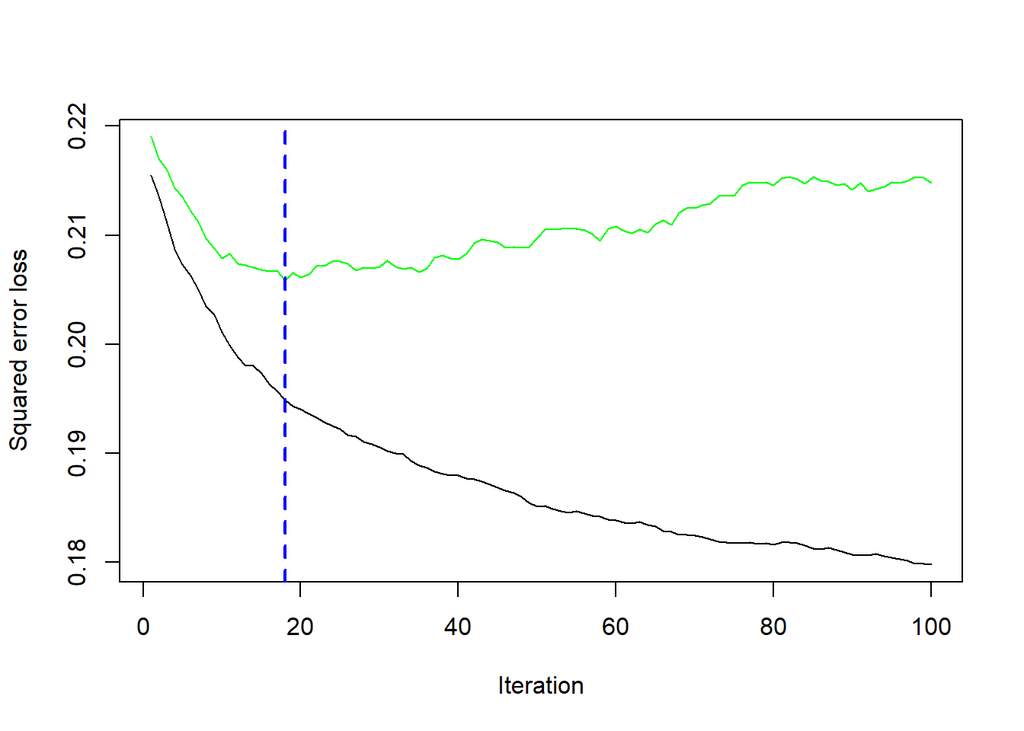

```
## [1] 18
```

```
## [1] 0.4577427
```

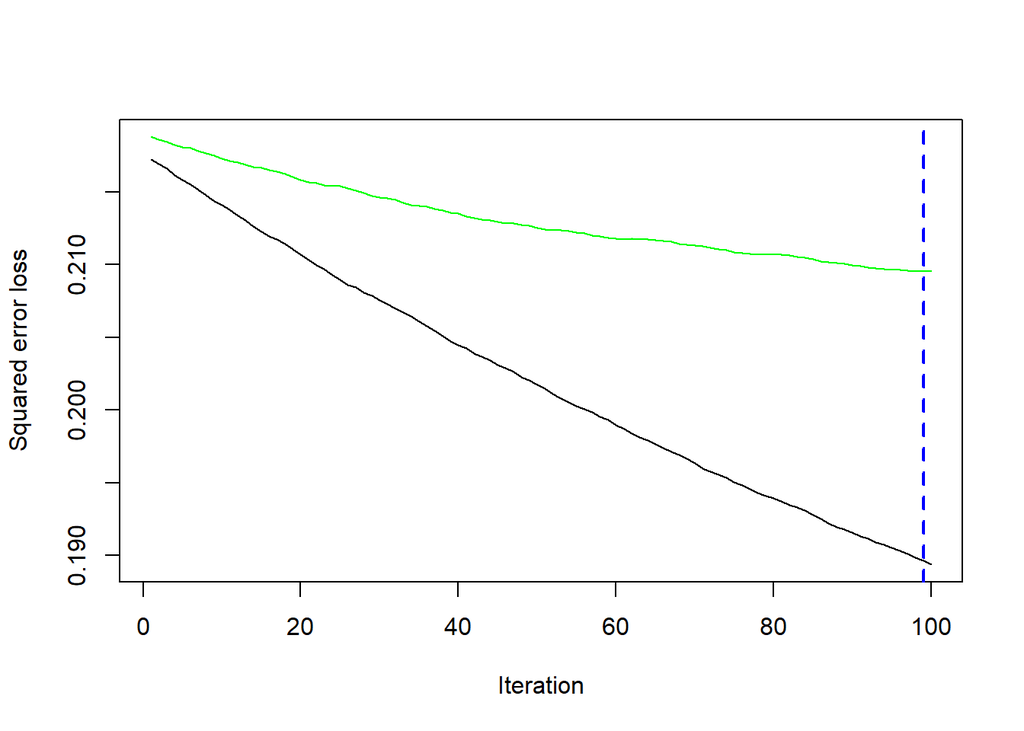

```
## [1] 99
```

```
##   n.trees shrinkage interaction.depth n.minobsinnode      rmse
## 1      20      0.01                 7             15 0.4637017
## 2      20      0.01                 5             15 0.4637185
## 3      20      0.01                 3             15 0.4638536
## 4      20      0.01                 3             10 0.4639421
## 5      20      0.01                 3              5 0.4639774
## 6      20      0.01                 5             10 0.4640834
## 7      20      0.01                 7             10 0.4641993
## 8      20      0.01                 5              5 0.4643627
## 9      20      0.01                 7              5 0.4648886
```

## Random Forests

I know that Decision Tree and Random Forest are not the best choices for small datasets since it is better to use a simple model but I want to see the effect of these models on my dataset and how it will affect the prediction results.

Random Forests Model results so RMSE = 0.5783877

```
## Ranger result
##
## Call:
##  ranger(formula = admit ~ ., data = coladm_train, num.trees = length(features) *      10, mtry = floor(length(features)/3), respect.unordered.factors = "order",      verbose = FALSE, seed = 123)
##
## Type:                             Classification
## Number of trees:                  60
## Sample size:                      278
## Number of independent variables:  6
## Mtry:                             2
## Target node size:                 1
## Variable importance mode:         none
## Splitrule:                        gini
## OOB prediction error:             33.45 %
```

```
## [1] 0.5783877
```

Now I could find characteristics to Consider

```
##           key value
## 1        rank     4
## 2         ses     3
## 3        Race     3
## 4       admit     2
## 5 Gender_Male     2
```

Tuning Random Forest Trees RMSE for each Tree

```
##  [1] 0.6142389 0.5689824 0.5814890 0.5814890 0.5752697 0.5561947 0.5594190
##  [8] 0.5594190 0.5658126 0.5658126 0.5689824 0.5689824 0.5658126 0.5689824
## [15] 0.5658126 0.5626249 0.5594190 0.5561947 0.5626249 0.5626249 0.5626249
## [22] 0.5626249 0.5594190 0.5689824 0.5721347 0.5689824 0.5689824 0.5721347
## [29] 0.5689824 0.5721347 0.5721347 0.5689824 0.5658126 0.5561947 0.5561947
## [36] 0.5626249 0.5689824 0.5689824 0.5752697 0.5721347 0.5689824 0.5721347
## [43] 0.5689824 0.5689824 0.5721347 0.5721347 0.5721347 0.5752697 0.5721347
## [50] 0.5752697
```

Here is the correlation for each of features and target.

```
## # A tibble: 21 x 3
##    row         col            corr
##    <chr>       <chr>         <dbl>
##  1 gre         gpa          0.339
##  2 admit       rank        -0.250
##  3 admit       gre          0.174
##  4 admit       gpa          0.138
##  5 gre         rank        -0.100
##  6 admit       ses         -0.0952
##  7 ses         Race        -0.0919
##  8 Gender_Male Race        -0.0612
##  9 Race        rank         0.0586
## 10 gre         Gender_Male  0.0523
## # ... with 11 more rows
```

```
## # A tibble: 0 x 3
## # ... with 3 variables: row <chr>, col <chr>, corr <dbl>
```

Tuning Using hyper grid

```
## [1] 90
```

```
##   mtry min.node.size replace sample.fraction rmse
## 1    0             1    TRUE             0.5   NA
## 2    0             1    TRUE             0.5   NA
## 3    1             1    TRUE             0.5   NA
## 4    1             1    TRUE             0.5   NA
## 5    2             1    TRUE             0.5   NA
## 6    0             3    TRUE             0.5   NA
```

Tuning results

```
##    mtry min.node.size replace sample.fraction rmse perc_gain
## 1     0             1    TRUE             0.5   NA        NA
## 2     0             1    TRUE             0.5   NA        NA
## 3     1             1    TRUE             0.5   NA        NA
## 4     1             1    TRUE             0.5   NA        NA
## 5     2             1    TRUE             0.5   NA        NA
## 6     0             3    TRUE             0.5   NA        NA
## 7     0             3    TRUE             0.5   NA        NA
## 8     1             3    TRUE             0.5   NA        NA
## 9     1             3    TRUE             0.5   NA        NA
## 10    2             3    TRUE             0.5   NA        NA
```

# Conclusion

This data does not provide enough elements to predict if a high school student got admitted or not and based on that the prediction model not very accurate so can’t tell for sure if a student is admitted or not.

This decision has a lot of outer factors that affect it like what are the other student grades that based on that the acceptance percentage can change and based on their GPA and GRE the acceptance process change entirely.

So this why I think this prediction is not good with the currently provided data also enhancing this prediction requires having larger data and in my opinion, this would help to be more accurate in the prediction so using small data for this prediction is a bad decision.

# Extra

KNN Model  
After Kaggle project I wanted to try implement KNN with my data to understand it better.

```
## k-Nearest Neighbors
##
## 278 samples
##   6 predictor
##   2 classes: '0', '1'
##
## No pre-processing
## Resampling: Cross-Validated (10 fold, repeated 5 times)
## Summary of sample sizes: 250, 250, 251, 251, 250, 250, ...
## Resampling results across tuning parameters:
##
##   k   Accuracy   Kappa
##    2  0.5766219   0.012056583
##    4  0.5861396  -0.012416255
##    6  0.6073077  -0.005607870
##    8  0.6273036   0.016992082
##   10  0.6115140  -0.041534485
##   12  0.6340069  -0.009625305
##   14  0.6317827  -0.036404757
##   16  0.6440354  -0.015208531
##   18  0.6467562  -0.026616308
##   20  0.6453541  -0.036438257
##   22  0.6619943  -0.004706120
##   24  0.6654599   0.002473754
##   26  0.6612556  -0.015517472
##
## Accuracy was used to select the optimal model using the largest value.
## The final value used for the model was k = 24.
```

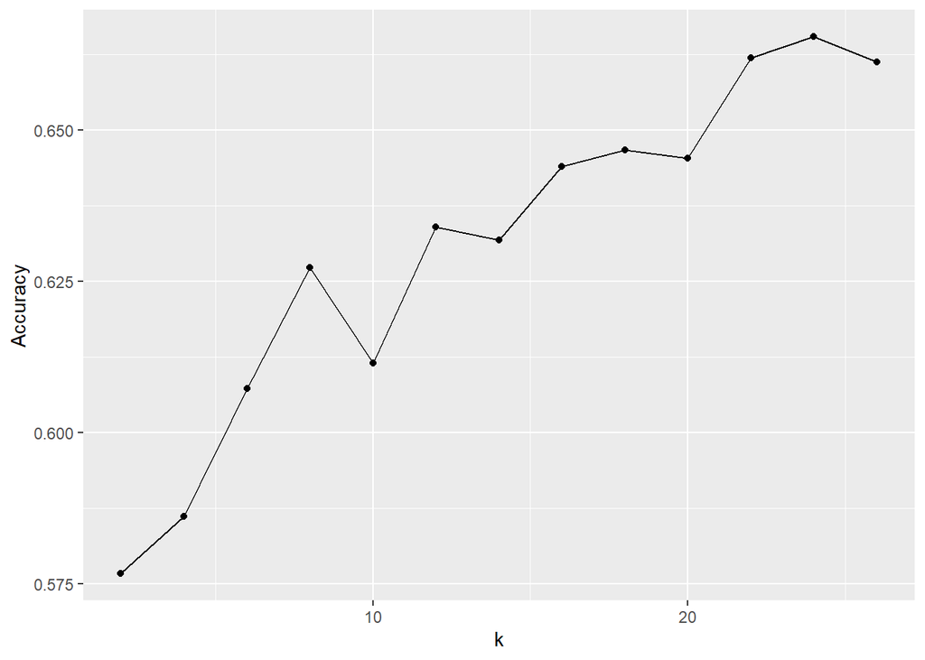